# 用Python做交互式画图

## —— IPython Notebook 与 Matplotlib

## 在天文中的应用

李昭洲 lizz@shao.ac.cn

上海天文台 星系宇宙学中心

## Python科学计算工作流

- IPython (Notebook)
  - 交互界面
- Numpy
  - 数组运算
- Scipy
  - 高级数值计算：求根、极值、特殊函数、统计……
- Pandas
  - 灵活的数据表，类似excel，长于处理多维观测数据
- Matplotlib
  - 画图，类似matlab/idl
- Sympy
  - 符号运算，类似mathematica

## 天文一些资源

- astropy
  - 最有野心的天文包
  - http://www.astropy.org/
- astropython
  - 天文Python使用者的门户：教程、新闻、代码片断
  - 非常全的天文包列表，看看有没有你要的
  - http://www.astropython.org/
- python4astronomers
  - 不错的教程
  - https://python4astronomers.github.io

## 目录

- IPython Notebook
- Matplotlib
- Examples

# IPython

## IPython

- 最好用的 Python 终端
- 支持历史命令、变量补全
- 交互式画图，`ipython --pylab`
- 友好的帮助系统
- 丰富的扩展

# IPython Notebook

## (Jupyter)

## IPython Notebook

- 类似 Mathematica Notebook
- 可以展示文本、公式、代码、计算结果、图形表格、音频、视频
- 支持 Markdown, LaTeX Math
- 语法高亮和命令补全
- 储存在 .ipynb 文件中
- 可以导出为 pdf 或 html

## 优点

- 同时展示代码与结果
- 方便传播交流，可重复研究

## 安装

- 推荐使用 **Anaconda**
- 推荐以非 root 用户安装

## 使用

1. 终端输入 `ipython notebook` 或 `jupyter-notebook`
2. 在浏览器中访问地址 `http://localhost:8888`

## 交互画图

- 在notebook中输入 `%pylab inline` 开启交互画图
- 后面详述

## Magic Commands

- !
  - 执行外部命令，如`!ls`，`!cd`
  - 返回结果可以赋值给变量，如`a=!ls`
- ?
  - 函数/变量 后加问号，呼出帮助
  - 如 `plot?` 或 `?plot`

```python
!ls
#我没在windows下测试过，如果不行，试试 !dir
```

```
Intro_IPython_Matplotlib.ipynb custom.css
M67.fits                       helix.jpg
Markdown.ipynb                 m101_blue.fits
bak
```

```python
a = !ls
print a
```

```
['Intro_IPython_Matplotlib.ipynb', 'M67.fits', 'Markdown.ipynb', 'bak', 'custom.css', 'helix.jpg', 'm101_blue.fits']
```

```python
dict?
```

## Magic Commands 2

- %timeit
  - 计时，显示完成某命令的用时
  - `%timeit func(x)`
- %prun
  - 显示被调用的各函数运行时间，用于找出热点，优化程序
  - `%prun func(x)`
- %debug
  - 调试：事故发生后，还原车祸现场，找出肇事者
  - 在新的cell中运行 `%debug`

```python
import time
def func1():
    time.sleep(0.5)
    func2()

def func2():
    time.sleep(0.1)
```

```python
%timeit func1()
```

```
1 loops, best of 3: 603 ms per loop
```

```python
%%timeit
func1()
func2()
```

```
1 loops, best of 3: 708 ms per loop
```

```python
%prun func1()
```

```python
%%prun
func2()
func1()
```

```python
def func1(a):
    func2(a)
def func2(a):
    b = 'string'
    print a + b
```

```python
func1(1)
```

```
---------------------------------------------------------------------------
TypeError                                 Traceback (most recent call last)
<ipython-input-76-63890d2d1c3d> in <module>()
----> 1 func1(1)

<ipython-input-75-64047318ea97> in func1(a)
      1 def func1(a):
----> 2     func2(a)
      3 def func2(a):
      4     b = 'string'
      5     print a + b

<ipython-input-75-64047318ea97> in func2(a)
      3 def func2(a):
      4     b = 'string'
----> 5     print a + b

TypeError: unsupported operand type(s) for +: 'int' and 'str'
```

```python
%debug
```

# 用 IPython Notebook 写笔记

在 IPython Notebook 工具栏中可以更改 cell 类型。

我们可以在 Markdown Cell 中写笔记。 （notebook 中双击 cell 查看原始文本。）

## Markdown Basic

# 一级标题

## 二级标题

- 列表
- 有序列表
  1. 项目一
  2. 项目二
- 表格

| name | age | weight |
| --- | --- | --- |
| Bob | 25 | 65 |
| Alice | 23 | 48 |

- 字体：*斜体*, **强调**, 删除

## Markdown Latex

- $\LaTeX$ inline math - $L_\odot/M_\odot$ represents light mass ratio of sun
- $\LaTeX$ display math $$ \rho_{crit}=\frac{3H^2}{8\pi \rm{G}}$$
- $\LaTeX$ equation eviroment $$\begin{aligned} \nabla \times \vec{\mathbf{B}} -\, \frac1c\, \frac{\partial\vec{\mathbf{E}}}{\partial t} & = \frac{4\pi}{c}\vec{\mathbf{j}} \\ \nabla \cdot \vec{\mathbf{E}} & = 4 \pi \rho \\ \nabla \times \vec{\mathbf{E}}\, +\, \frac1c\, \frac{\partial\vec{\mathbf{B}}}{\partial t} & = \vec{\mathbf{0}} \\ \nabla \cdot \vec{\mathbf{B}} & = 0 \end{aligned}$$

## Markdown Code

- code inline: `ipython notebook`
- code block with syntex highlight

  ```
  def func(x):
    return x*2
  class bar:
    def __init__(self, x):
        self.x = x
  ```

## Markdown Image

Here's a image

[figure not shown]

# Matplotlib

## Matplotlib

- `Python` 世界的基础图形包
- 作图命令与 `matlab` 非常相似
- 看看能画什么： 点击[图集](http://matplotlib.org/gallery.html)
- 优点：出图快，默认设置美观，可粗可细
- 细节很多，边用边学，按需使用

## 资源

- [快速入门](http://reverland.org/python/2012/09/07/matplotlib-tutorial/)
- [Matplotlib Gallary](http://matplotlib.org/gallery.html)
  - 看看有没有与你目标相似的图
- [Matplotlib Document](http://matplotlib.org/contents.html)
  - 命令不知道怎么用？
- [Stack Overflow](http://stackoverflow.com)
  - 专业问答社区
- 身边专家

## 使用

### `pylab`模式

- `matplotlib.pylab` 中提供了类似 `matlab` 的计算与作图常用函数
- 在脚本中使用
  - `from pylab import *`
- 在 notebook 中使用
  - 在 notebook 的 cell 中输入并运行 `%pylab inline`
- 在 ipython 中使用
  - 在 *终端* 中输入 `ipython --pylab`
  - 或者在 `ipython` 中输入 `%pylab`

```python
%pylab inline
```

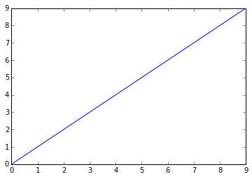

```python
plot(arange(10))
```

# Matplotlib 示例1 - 基础

## 基础画图命令

- 线图：plot
- 坐标：xlabel, ylabel, xlim, ylim
- 标题：title
- 保存：savefig

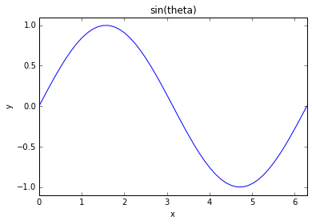

```python
%pylab inline
x = linspace(0, 2, 51) * pi
y = sin(x)

plot(x, y)
xlabel('x')
ylabel('y')
xlim(0,2*pi)
ylim(-1.1,1.1)
title('sin(theta)')
savefig('sin_theta.pdf')
```

```python
#Let's have a try
```

## 更多细节

- 线型，线宽，颜色，透明度：keywords - ls, lw, color, alpha
- 图例：legend
- 图注：annotate
- 字体：keywords - fontsize
- LaTeX： `r"$\latex$"`
- 关闭： close

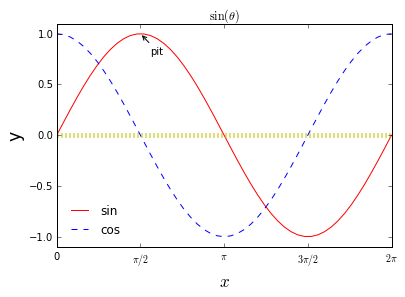

```python
x = linspace(0, 2, 51) * pi
y1, y2 = sin(x), cos(x)

plot(x, y1, 'r-', label=r'sin')
plot(x, y2, 'b--', label=r'cos')
axhline(0, color='y', ls=':', lw=5)
annotate('pit', (pi/2,1), xytext=(pi/2+0.2, 0.8),
         arrowprops=dict(arrowstyle="->"))
xlabel(r'$x$', fontsize='xx-large')
ylabel('y', fontsize='xx-large')
xlim(0, 2*pi)
ylim(-1.1, 1.1)
xticks(arange(0,2.01,0.5)*pi,
       [r'0', r'$\pi/2$', r'$\pi$', r'$3\pi/2$', r'$2\pi$'])
title(r'$\sin(\theta)$')
legend(loc=3, frameon=False)
savefig('sin_theta2.pdf')
```

```python
#Let's have a try
```

## 图与子图

- `figure`：图，可以看做画布
  - 用 `figure` 函数生成 `Figure` 对象
- `axes`：子图，一个图中可以有多个子图
  - 用 `subplot` 生成 `Axes` 对象
  - 用 `subplots` 一次性生成多个子图
- `gcf/gca` 获得当前图/子图
- `scf/sca` 设定当前图/子图
- `clf/cla` 清空当前图/子图

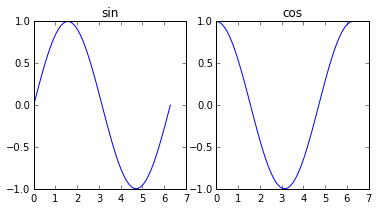

```python
figure(figsize=(6,3))

subplot(121)
plot(x, y1)
title('sin')

subplot(122)
plot(x, y2)
title('cos')
```

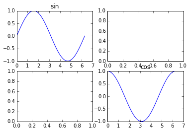

```python
fig, axs = subplots(2,2) # here axs is a array of axes
sca(axs[0,0])
plot(x, y1)
title('sin')
sca(axs[1,1])
plot(x, y2)
title('cos')
```

```python
axs
```

[output not shown]

使用帮助命令，查看以下函数用法

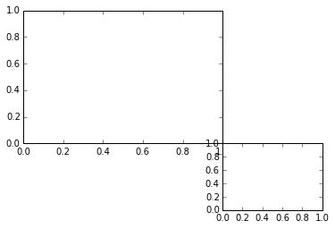

```python
subplot2grid((3,3),(0,0), 2, 2)
subplot2grid((3,3),(2,2), 1, 1)
subplots_adjust(hspace=0, wspace=0)
```

## 常用作图

请多参考[Gallery](http://matplotlib.org/gallery.html)

- 误差棒：errorbar
- 填充色块：fill_betweeen
- 直方图：hist
- 2d直方图: hist2d
- 散点图：scatter
- 等高线：contour
- 显示图像：imshow

## Errorbar

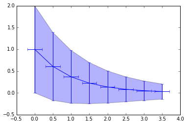

```python
x = arange(0, 4, 0.5)
y = exp(-x)
yerr = sqrt(y)

errorbar(x, y, xerr=0.2, yerr=yerr)
fill_between(x, y-yerr, y+yerr, alpha=0.3)
```

## Histogram

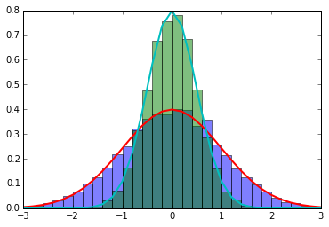

```python
a = randn(10000)
hist(a, linspace(-3,3,31), normed=True, alpha=0.5)

b = randn(10000) / 2
hist(b, linspace(-3,3,31), normed=True, alpha=0.5)

from scipy.stats import norm
x = linspace(-3, 3, 31)
plot(x, norm.pdf(x), lw=2)
plot(x, norm.pdf(x, scale=0.5), lw=2)
```

## 面向对象作图

Figrue, Axes都是对象。我们可以直接调用它们自带函数。如

```python
fig = figure()
ax = subplot()
ax.plot(arange(10))
ax.set_xlabel('x')
```

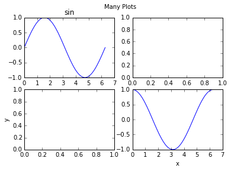

```python
fig, axs = subplots(2,2) # here axs is a array of axes
fig.suptitle('Many Plots')

axs[0,0].plot(x, y1)
axs[0,0].set_title('sin')

axs[1,1].plot(x, y2)
axs[1,1].set_xlabel('x')

ax = axs[1, 0]
ax.set_ylabel('y')
fig.savefig('subplots.pdf')
```

# Matplotlib 示例2 - HR Diagram

数据下载： http://pan.baidu.com/s/1DPjzg

将 fits 文件下载到当前 notebook 所在的文件夹中。

```python
#如果你不知道当前文件夹的位置，请运行
!pwd
```

```
/Users/lizz/Desktop/slides
```

```python
#for windows user, you may try
!echo %cd%
#I'm not sure this would work， I've not windows in hand :(
```

```
%cd%
```

读入数据

```python
%pylab inline
from astropy.io import fits
unit1, unit2 = fits.open('M67.fits')
data = unit2.data
J, H, K, eJ, eH, eK =  data["Jmag"], data['Hmag'], \
    data['Kmag'], data["e_Jmag"],\
    data["e_Hmag"],data["e_Kmag"]

#J, H, K, eJ, eH, eK = [data[k.strip()] for k in
#    "Jmag,Hmag,Kmag,e_Jmag,e_Hmag,e_Kmag".split(',')]
```

```python
fig = figure(figsize=(12,6))

subplot(121)
scatter(J-H, J, s=10, edgecolor='none')
xlim(0,1)
ylim(18, 8)

xlabel(r'color J-H (Magnitudes)', fontsize='xx-large')
xticks(fontsize='xx-large')
ylabel(r'apparent J magnitude')
title(r'color-magnitude diagram')

subplot(122)
hist2d(J-H, J, (linspace(0,1, 31), linspace(8, 18, 31)),
       normed=True, cmap='cool')
xlim(0,1)
ylim(18, 8)
colorbar()

subplots_adjust(wspace=0)
yticks([])

close()
```

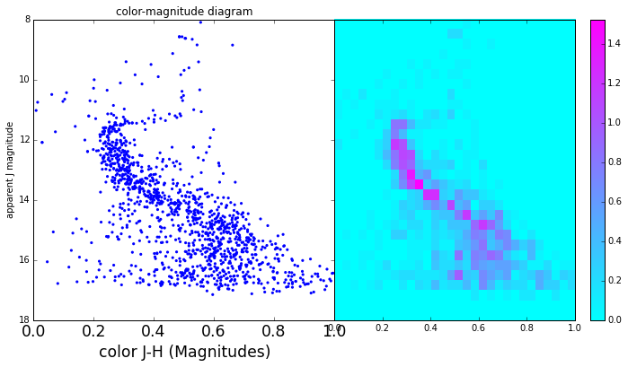

```python
fig
```

上面的图太丑了，不能见人？没问题。

参考[这里](http://matplotlib.org/mpl_toolkits/axes_grid/users/overview.html#axes-grid1)，`AxesGrid`提供了各种版式，满足你复杂需求

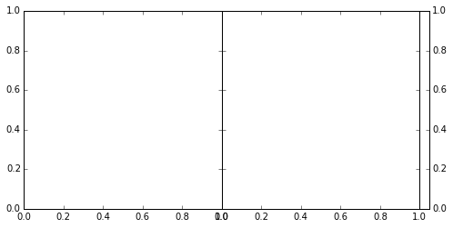

```python
from mpl_toolkits.axes_grid1 import AxesGrid
fig = figure(figsize=(8,4))
grid = AxesGrid(fig, 111, nrows_ncols=(1, 2),
                axes_pad=0.0, share_all=True,
                cbar_location="right", cbar_mode="single")
#Let's finish it
```

# Matplotlib 示例3 - FITS图像

## 问题

- 如何将CCD坐标转为世界坐标

## 可能有用的包

- WCSAxes
  - 已成为astropy子包
- APLpy
  - Astronomical Plotting Library in Python

```python
#如果没有WCSAxes包，在cell中运行
!pip install WCSAxes
```

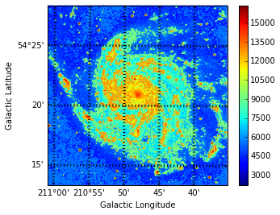

```python
from astropy.io import fits
from astropy import wcs
hdu = fits.open('m101_blue.fits')[0]
wc = wcs.WCS(hdu.header)

figure(figsize=(5,4))
ax = subplot(projection=wc)
imshow(hdu.data, origin='lower') #留意origin='lower'
#xlim(0,500)
ax.coords.grid(color='k', lw=3)
colorbar()

contour(log10(hdu.data), 5)
xlabel('Galactic Longitude')
ylabel('Galactic Latitude')
```

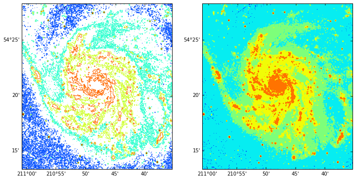

```python
figure(figsize=(12,6))
ax = subplot(121, projection=wc)
contour(log10(hdu.data), 6)

ax = subplot(122, projection=wc)
contourf(log10(hdu.data), 6)
```

# Questions

# Thank you

# Supplemental Material

## 一些推荐教程

- Python
  - Online Python Tutor：初学者不可错过的网站
  - [Python入门](http://www.math.pku.edu.cn/teachers/lidf/docs/Python/python-tutorial.html) ：最精简的教程
  - [A Byte of Python](https://github.com/onion7878/A-Byte-of-Python-CN) ：稍微详细一点的教程
- Numpy
  - http://reverland.org/python/2012/08/22/numpy/
- Matplotlib
  - http://reverland.org/python/2012/09/07/matplotlib-tutorial/
- For IDL user
  - http://mathesaurus.sourceforge.net/idl-numpy.html
- For Matlab user
  - http://wiki.scipy.org/NumPy_for_Matlab_Users

## Numpy中多个条件筛选

numpy bool 数组支持用 `~ & |` 做逻辑运算，注意这里不能用`not/and/or`。

```
data = rand(10)
x, y, z = rand(10), rand(10), rand(10)
a, b, c = 0.3, 0.7, 0.5

idx = (x > a) | (y < b) & (z > c)
data_select = data[idx]
```

不少人遇到过这个问题，所以附在这里。

## 若干高级专题

如有需要，以后我们可以再讨论交流

- 天文中的读写文件
- 用 `python` 脚本批量下载网络数据
- 使用 `hdf5` 格式储存数据
- 用 `Cython` 写 `C` 扩展
- 多核并行
- MCMC 方法